# Изучение закономерностей, определяющих успешность игр

## Введение

### Описание проекта

Я работаю в интернет-магазине «Стримчик», который продаёт по всему миру компьютерные игры. Из открытых источников доступны исторические данные о продажах игр, оценки пользователей и экспертов, жанры и платформы (например, Xbox или PlayStation).

Мне необходимо выявить определяющие успешность игры закономерности. Это позволит сделать ставку на потенциально популярный продукт и спланировать рекламные кампании.

Передо мной данные до 2016 года. Представим, что сейчас декабрь 2016 г., и я планирую кампанию на 2017-й. Нужно отработать принцип работы с данными.

### Описание данных

1. Name — название игры
2. Platform — платформа
3. Year_of_Release — год выпуска
4. Genre — жанр игры
5. NA_sales — продажи в Северной Америке (миллионы проданных копий)
6. EU_sales — продажи в Европе (миллионы проданных копий)
7. JP_sales — продажи в Японии (миллионы проданных копий)
8. Other_sales — продажи в других странах (миллионы проданных копий)
9. Critic_Score — оценка критиков (максимум 100)
10. User_Score — оценка пользователей (максимум 10)
11. Rating — рейтинг от организации ESRB (англ. Entertainment Software Rating Board). Эта ассоциация определяет рейтинг компьютерных игр и присваивает им подходящую возрастную категорию.

## Загрузка данных

```python
pip install missingno
```

```python
#импорт библиотек
import pandas as pd
import copy
import matplotlib.pyplot as plt
import seaborn as sns
from scipy import stats as st
import numpy as np
import missingno as msno
```

```python
#загрузим наши данные
try:
    games = pd.read_csv('/datasets/games.csv')
except:
    games = pd.read_csv('https://code.s3.yandex.net/datasets/games.csv')
games
```

|  | Name | Platform | Year_of_Release | Genre | NA_sales | EU_sales | JP_sales | Other_sales | Critic_Score | User_Score | Rating |
| --- | --- | --- | --- | --- | --- | --- | --- | --- | --- | --- | --- |
| 0 | Wii Sports | Wii | 2006.0 | Sports | 41.36 | 28.96 | 3.77 | 8.45 | 76.0 | 8 | E |
| 1 | Super Mario Bros. | NES | 1985.0 | Platform | 29.08 | 3.58 | 6.81 | 0.77 | NaN | NaN | NaN |
| 2 | Mario Kart Wii | Wii | 2008.0 | Racing | 15.68 | 12.76 | 3.79 | 3.29 | 82.0 | 8.3 | E |
| 3 | Wii Sports Resort | Wii | 2009.0 | Sports | 15.61 | 10.93 | 3.28 | 2.95 | 80.0 | 8 | E |
| 4 | Pokemon Red/Pokemon Blue | GB | 1996.0 | Role-Playing | 11.27 | 8.89 | 10.22 | 1.00 | NaN | NaN | NaN |
| ... | ... | ... | ... | ... | ... | ... | ... | ... | ... | ... | ... |
| 16710 | Samurai Warriors: Sanada Maru | PS3 | 2016.0 | Action | 0.00 | 0.00 | 0.01 | 0.00 | NaN | NaN | NaN |
| 16711 | LMA Manager 2007 | X360 | 2006.0 | Sports | 0.00 | 0.01 | 0.00 | 0.00 | NaN | NaN | NaN |
| 16712 | Haitaka no Psychedelica | PSV | 2016.0 | Adventure | 0.00 | 0.00 | 0.01 | 0.00 | NaN | NaN | NaN |
| 16713 | Spirits & Spells | GBA | 2003.0 | Platform | 0.01 | 0.00 | 0.00 | 0.00 | NaN | NaN | NaN |
| 16714 | Winning Post 8 2016 | PSV | 2016.0 | Simulation | 0.00 | 0.00 | 0.01 | 0.00 | NaN | NaN | NaN |

16715 rows × 11 columns

```python
#посмотрим общую информацию о данных
games.describe()
```

|  | Year_of_Release | NA_sales | EU_sales | JP_sales | Other_sales | Critic_Score |
| --- | --- | --- | --- | --- | --- | --- |
| count | 16446.000000 | 16715.000000 | 16715.000000 | 16715.000000 | 16715.000000 | 8137.000000 |
| mean | 2006.484616 | 0.263377 | 0.145060 | 0.077617 | 0.047342 | 68.967679 |
| std | 5.877050 | 0.813604 | 0.503339 | 0.308853 | 0.186731 | 13.938165 |
| min | 1980.000000 | 0.000000 | 0.000000 | 0.000000 | 0.000000 | 13.000000 |
| 25% | 2003.000000 | 0.000000 | 0.000000 | 0.000000 | 0.000000 | 60.000000 |
| 50% | 2007.000000 | 0.080000 | 0.020000 | 0.000000 | 0.010000 | 71.000000 |
| 75% | 2010.000000 | 0.240000 | 0.110000 | 0.040000 | 0.030000 | 79.000000 |
| max | 2016.000000 | 41.360000 | 28.960000 | 10.220000 | 10.570000 | 98.000000 |

```python
games.info()
```

```
<class 'pandas.core.frame.DataFrame'>
RangeIndex: 16715 entries, 0 to 16714
Data columns (total 11 columns):
 #   Column           Non-Null Count  Dtype
---  ------           --------------  -----
 0   Name             16713 non-null  object
 1   Platform         16715 non-null  object
 2   Year_of_Release  16446 non-null  float64
 3   Genre            16713 non-null  object
 4   NA_sales         16715 non-null  float64
 5   EU_sales         16715 non-null  float64
 6   JP_sales         16715 non-null  float64
 7   Other_sales      16715 non-null  float64
 8   Critic_Score     8137 non-null   float64
 9   User_Score       10014 non-null  object
 10  Rating           9949 non-null   object
dtypes: float64(6), object(5)
memory usage: 1.4+ MB
```

Итак, уже на данном этапе видны пропуски, причем большое количество. Также следует в дальнейшем привести названия столбцов к корректному формату, исправить типы данных и проверить дубликаты.

## Предобработка данных

```python
#Начнем с названий столбцов
games.columns
```

```
Index(['Name', 'Platform', 'Year_of_Release', 'Genre', 'NA_sales', 'EU_sales',
       'JP_sales', 'Other_sales', 'Critic_Score', 'User_Score', 'Rating'],
      dtype='object')
```

```python
#приведем названия к нижнему регистру
games.columns = games.columns.str.lower()
#Проверим
games.columns
```

```
Index(['name', 'platform', 'year_of_release', 'genre', 'na_sales', 'eu_sales',
       'jp_sales', 'other_sales', 'critic_score', 'user_score', 'rating'],
      dtype='object')
```

```python
#приведем столбец с датой к типу Int32
games['year_of_release'] = games['year_of_release'].astype('Int32')
```

```python
#выведем уникальные значения в оценках пользователей
games['user_score'].unique()
```

```
array(['8', nan, '8.3', '8.5', '6.6', '8.4', '8.6', '7.7', '6.3', '7.4',
       '8.2', '9', '7.9', '8.1', '8.7', '7.1', '3.4', '5.3', '4.8', '3.2',
       '8.9', '6.4', '7.8', '7.5', '2.6', '7.2', '9.2', '7', '7.3', '4.3',
       '7.6', '5.7', '5', '9.1', '6.5', 'tbd', '8.8', '6.9', '9.4', '6.8',
       '6.1', '6.7', '5.4', '4', '4.9', '4.5', '9.3', '6.2', '4.2', '6',
       '3.7', '4.1', '5.8', '5.6', '5.5', '4.4', '4.6', '5.9', '3.9',
       '3.1', '2.9', '5.2', '3.3', '4.7', '5.1', '3.5', '2.5', '1.9', '3',
       '2.7', '2.2', '2', '9.5', '2.1', '3.6', '2.8', '1.8', '3.8', '0',
       '1.6', '9.6', '2.4', '1.7', '1.1', '0.3', '1.5', '0.7', '1.2',
       '2.3', '0.5', '1.3', '0.2', '0.6', '1.4', '0.9', '1', '9.7'],
      dtype=object)
```

TBD (To Be Determined) — английское выражение, которое переводится на русский язык как «Будет определено». В играх этот термин используется для обозначения функции, возможности или содержания, которые в настоящее время еще не завершены или не определены разработчиками. Как правило, фраза TBD появляется на различных этапах разработки игры, когда возникают еще открытые вопросы или решения отложены на будущее.

Полагаю, что данное значение можно заменить на "Nan", потому как оно равносильно значению, которое нам неизвестно.

```python
#Заменяем tbd на Nan
games['user_score'] = games['user_score'].replace('tbd', np.NaN).astype('float32')
games.info()
```

```
<class 'pandas.core.frame.DataFrame'>
RangeIndex: 16715 entries, 0 to 16714
Data columns (total 11 columns):
 #   Column           Non-Null Count  Dtype
---  ------           --------------  -----
 0   name             16713 non-null  object
 1   platform         16715 non-null  object
 2   year_of_release  16446 non-null  Int32
 3   genre            16713 non-null  object
 4   na_sales         16715 non-null  float64
 5   eu_sales         16715 non-null  float64
 6   jp_sales         16715 non-null  float64
 7   other_sales      16715 non-null  float64
 8   critic_score     8137 non-null   float64
 9   user_score       7590 non-null   float32
 10  rating           9949 non-null   object
dtypes: Int32(1), float32(1), float64(5), object(4)
memory usage: 1.3+ MB
```

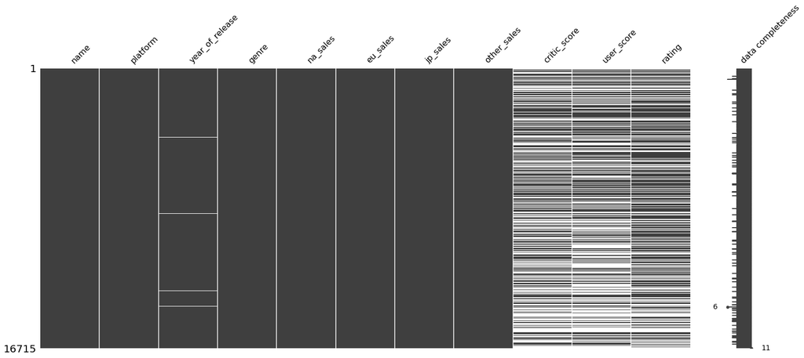

```python
#рассмотрим, в каких столбцах пропуски
msno.matrix(games, labels=True)
```

```python
games['year_of_release'].describe()
```

```
count    16446.000000
mean      2006.484616
std          5.877050
min       1980.000000
25%       2003.000000
50%       2007.000000
75%       2010.000000
max       2016.000000
Name: year_of_release, dtype: float64
```

Пропуски в year_of_release мы обработать не можем, так как нам попросту неизвестен год. Можно было бы попробовать взять данный год выпуска этих игр с других платформ. Но не на всех платформах одна и та же игра выходит в один и тот же период времени. Поэтому оставляем пропуски.

Пропуски в рейтинге критиков и пользователей также оставляем. Заполнять их медианой или средним будет неправильно, поскольку это сильно отразится на выводах исследования.

Пропуски в рейтинге ESRB тоже оставляем, так как не знаем информации для их заполнения.

**Таким образом, мы не можем заполнить или удалить пропуски, все оставляем как есть.**

Полагаю, что пропуски связаны с годом выпуска игр. Раньше критики и пользователи не оценивали игры, от того и пропуски. Касаемо последнего столбца (рейтинг ESRB), данная организация появилась лишь в 1994 году. В наших данных имеются игры, выпускаемые еще с 1980 года. Соответственно для игр, выпущенных в 1980-1993 гг, рейтинг остался пустым.

```python
games['rating'].fillna('without', inplace= True)
```

```python
games.head(3)
```

|  | name | platform | year_of_release | genre | na_sales | eu_sales | jp_sales | other_sales | critic_score | user_score | rating |
| --- | --- | --- | --- | --- | --- | --- | --- | --- | --- | --- | --- |
| 0 | Wii Sports | Wii | 2006 | Sports | 41.36 | 28.96 | 3.77 | 8.45 | 76.0 | 8.0 | E |
| 1 | Super Mario Bros. | NES | 1985 | Platform | 29.08 | 3.58 | 6.81 | 0.77 | NaN | NaN | without |
| 2 | Mario Kart Wii | Wii | 2008 | Racing | 15.68 | 12.76 | 3.79 | 3.29 | 82.0 | 8.3 | E |

```python
#проверим наличие дубликатов
games.duplicated().sum()
```

```
0
```

```python
#вычисляем количество строк до удаления дубликатов
len(games)
```

```
16715
```

```python
#проверяем дубликаты по сочетанию признаков: название игры - платформа - год выпуска
duplicate_rows = games[games.duplicated(['name', 'platform', 'year_of_release'])]
duplicate_rows
```

|  | name | platform | year_of_release | genre | na_sales | eu_sales | jp_sales | other_sales | critic_score | user_score | rating |
| --- | --- | --- | --- | --- | --- | --- | --- | --- | --- | --- | --- |
| 14244 | NaN | GEN | 1993 | NaN | 0.0 | 0.00 | 0.03 | 0.0 | NaN | NaN | without |
| 16230 | Madden NFL 13 | PS3 | 2012 | Sports | 0.0 | 0.01 | 0.00 | 0.0 | 83.0 | 5.5 | E |

```python
#Удаляем два дубликата, которые мы выявили
games = games.drop_duplicates(['name', 'platform', 'year_of_release']).reset_index(drop=True)
```

```python
#проверяем, что удалились две строки
len(games)
```

```
16713
```

**Далее рассчитаем суммарные продажи во всех регионах и запишем их в отдельный столбец:**

```python
games['all_sales'] = games['na_sales'] + games['eu_sales'] + games['jp_sales'] + games['other_sales']
#проверим
games.head(3)
```

|  | name | platform | year_of_release | genre | na_sales | eu_sales | jp_sales | other_sales | critic_score | user_score | rating | all_sales |
| --- | --- | --- | --- | --- | --- | --- | --- | --- | --- | --- | --- | --- |
| 0 | Wii Sports | Wii | 2006 | Sports | 41.36 | 28.96 | 3.77 | 8.45 | 76.0 | 8.0 | E | 82.54 |
| 1 | Super Mario Bros. | NES | 1985 | Platform | 29.08 | 3.58 | 6.81 | 0.77 | NaN | NaN | without | 40.24 |
| 2 | Mario Kart Wii | Wii | 2008 | Racing | 15.68 | 12.76 | 3.79 | 3.29 | 82.0 | 8.3 | E | 35.52 |

**Вывод по предобработке:**

На шаге предобработки данных были приведены к нижнему регистру названия столбцов, изменен тип данных в столбце year_of_release, проверено наличие пропусков в столбцах и выявлено, что данные пропуски невозможно ничем заменить, также были проверены данные на явные дубликаты, рассчитаны суммарные продажи во всех регионах и добавлены в новый столбец (all_sales).

## Исследовательский анализ данных

**Узнаем сколько игр выпускалось в разные годы**

```python
year_of_release_pt = pd.pivot_table(games, index='year_of_release', values='name', aggfunc='count')
year_of_release_pt.columns = ['count']
year_of_release_pt
```

| year_of_release | count |
| --- | --- |
| 1980 | 9 |
| 1981 | 46 |
| 1982 | 36 |
| 1983 | 17 |
| 1984 | 14 |
| 1985 | 14 |
| 1986 | 21 |
| 1987 | 16 |
| 1988 | 15 |
| 1989 | 17 |
| 1990 | 16 |
| 1991 | 41 |
| 1992 | 43 |
| 1993 | 60 |
| 1994 | 121 |
| 1995 | 219 |
| 1996 | 263 |
| 1997 | 289 |
| 1998 | 379 |
| 1999 | 338 |
| 2000 | 350 |
| 2001 | 482 |
| 2002 | 829 |
| 2003 | 775 |
| 2004 | 762 |
| 2005 | 939 |
| 2006 | 1006 |
| 2007 | 1197 |
| 2008 | 1427 |
| 2009 | 1426 |
| 2010 | 1255 |
| 2011 | 1136 |
| 2012 | 652 |
| 2013 | 544 |
| 2014 | 581 |
| 2015 | 606 |
| 2016 | 502 |

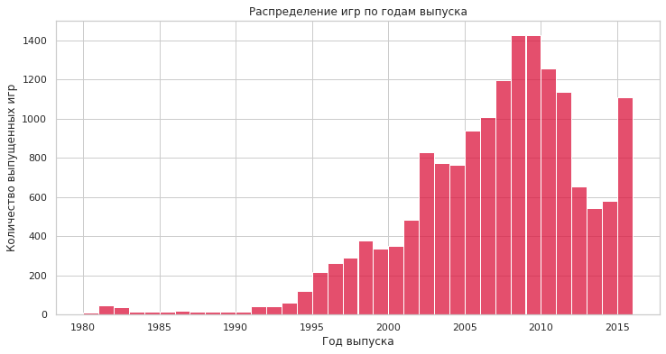

```python
#визуализируем выпуск игр в разные годы
sns.set(style="whitegrid")
plt.figure(figsize=(12, 6))

# Визуализируем выпуск игр в разные годы с помощью гистограммы
sns.histplot(games['year_of_release'], bins=range(games['year_of_release'].min(), games['year_of_release'].max() + 1, 1), kde=False, color='crimson')

# Добавляем заголовок и метки осей
plt.title('Распределение игр по годам выпуска')
plt.xlabel("Год выпуска")
plt.ylabel("Количество выпущенных игр")
plt.grid(True)

plt.show()
```

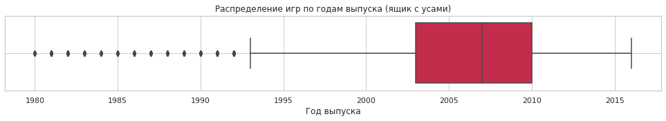

```python
# Строим ящик с усами
plt.figure(figsize=(17, 2))
sns.boxplot(x=games['year_of_release'], color='crimson')

# Добавляем заголовок и метки осей
plt.title('Распределение игр по годам выпуска (ящик с усами)')
plt.xlabel("Год выпуска")
plt.grid(True)

plt.show()
```

**Посмотрим, как менялись продажи по платформам**

```python
#создаем сводную таблицу
platforms_pt = games.pivot_table(
                                 index = ['platform'],
                                 values = ['all_sales'],
                                 aggfunc =  ['sum'])
platforms_pt.sort_values(('sum', 'all_sales'),ascending = False)
```

| platform | sum all_sales |
| --- | --- |
| PS2 | 1255.77 |
| X360 | 971.42 |
| PS3 | 939.64 |
| Wii | 907.51 |
| DS | 806.12 |
| PS | 730.86 |
| GBA | 317.85 |
| PS4 | 314.14 |
| PSP | 294.05 |
| PC | 259.52 |
| 3DS | 259.00 |
| XB | 257.74 |
| GB | 255.46 |
| NES | 251.05 |
| N64 | 218.68 |
| SNES | 200.04 |
| GC | 198.93 |
| XOne | 159.32 |
| 2600 | 96.98 |
| WiiU | 82.19 |
| PSV | 54.07 |
| SAT | 33.59 |
| GEN | 30.74 |
| DC | 15.95 |
| SCD | 1.86 |
| NG | 1.44 |
| WS | 1.42 |
| TG16 | 0.16 |
| 3DO | 0.10 |
| GG | 0.04 |
| PCFX | 0.03 |

**Выберем платформы с наибольшими суммарными продажами и построим распределение по годам**

Выбираем следующие 6 платформ: PS2, X360, PS3, Wii, DS, PS. Именно они являются платформами с наибольшими продажами в сумме.

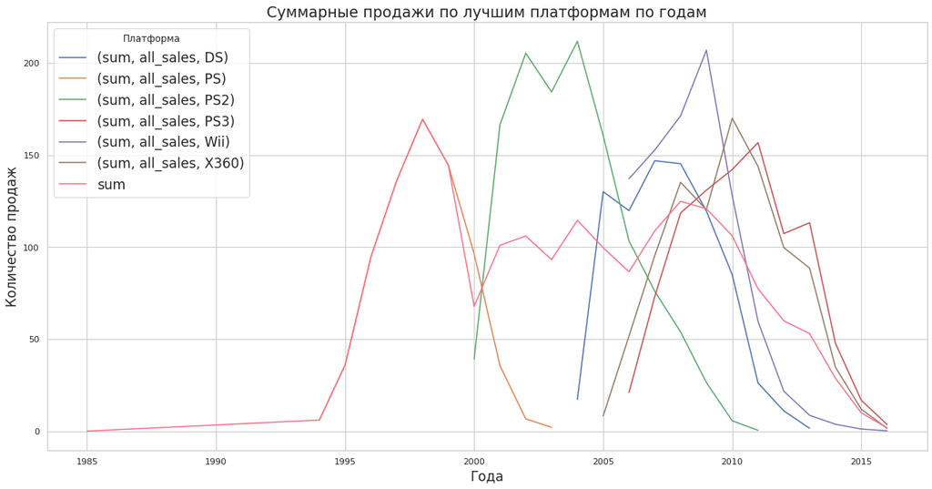

```python
#визуализируем сроки жизни лучших платформ
best_platforms = games.query('platform == ["PS2","X360","PS3","Wii","DS","PS"]').pivot_table(
                                 index = ['year_of_release'], \
                                 columns = ['platform'],
                                 values = ['all_sales'],
                                 aggfunc =  ['sum'])
best_platforms.plot(figsize = (20,10), grid=True)
colors = sns.color_palette("husl", len(best_platforms.columns.levels[1]))
sns.lineplot(data=best_platforms, palette=colors, ci=None)
# Добавляем заголовок и метки осей
plt.title("Суммарные продажи по лучшим платформам по годам", fontsize=19)
plt.xlabel("Года", fontsize=17)
plt.ylabel("Количество продаж", fontsize=17)
plt.legend(title='Платформа', loc='upper left', fontsize=17)
plt.grid(True)
plt.show()
```

**Также ниже рассмотрим распределение продаж по каждой платформе по отдельности:**

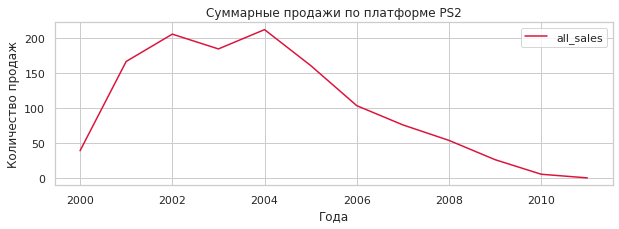

```python
games[games['platform'] == "PS2"].pivot_table(index='year_of_release', values='all_sales',
                                              aggfunc='sum').plot(kind='line',
                                                                  grid=True, figsize=(10,3), color='crimson')
plt.title("Суммарные продажи по платформе PS2")
plt.xlabel("Года")
plt.ylabel("Количество продаж")
plt.show()
```

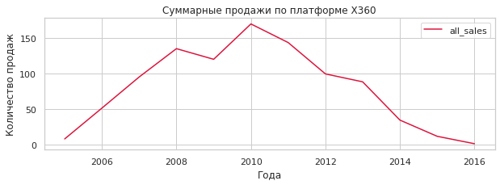

```python
games[games['platform'] == "X360"].pivot_table(index='year_of_release', values='all_sales',
                                              aggfunc='sum').plot(kind='line',
                                                                  grid=True, figsize=(10,3), color='crimson')
plt.title("Суммарные продажи по платформе X360")
plt.xlabel("Года")
plt.ylabel("Количество продаж")
plt.show()
```

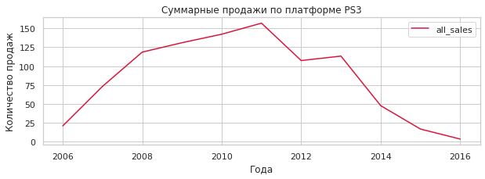

```python
games[games['platform'] == "PS3"].pivot_table(index='year_of_release', values='all_sales',
                                              aggfunc='sum').plot(kind='line',
                                                                  grid=True, figsize=(10,3), color='crimson')
plt.title("Суммарные продажи по платформе PS3")
plt.xlabel("Года")
plt.ylabel("Количество продаж")
plt.show()
```

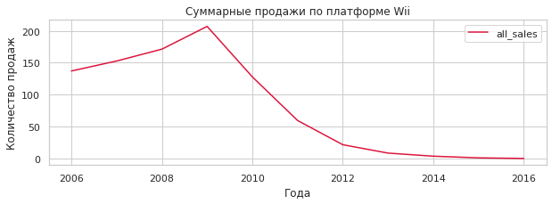

```python
games[games['platform'] == "Wii"].pivot_table(index='year_of_release', values='all_sales',
                                              aggfunc='sum').plot(kind='line',
                                                                  grid=True, figsize=(10,3), color='crimson')
plt.title("Суммарные продажи по платформе Wii")
plt.xlabel("Года")
plt.ylabel("Количество продаж")
plt.show()
```

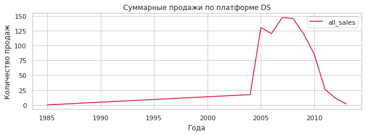

```python
games[games['platform'] == "DS"].pivot_table(index='year_of_release', values='all_sales',
                                              aggfunc='sum').plot(kind='line',
                                                                  grid=True, figsize=(10,3), color='crimson')
plt.title("Суммарные продажи по платформе DS")
plt.xlabel("Года")
plt.ylabel("Количество продаж")
plt.show()
```

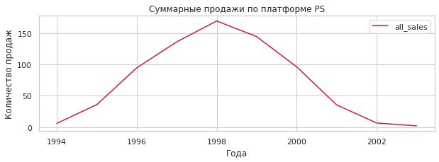

```python
games[games['platform'] == "PS"].pivot_table(index='year_of_release', values='all_sales',
                                              aggfunc='sum').plot(kind='line',
                                                                  grid=True, figsize=(10,3), color='crimson')
plt.title("Суммарные продажи по платформе PS")
plt.xlabel("Года")
plt.ylabel("Количество продаж")
plt.show()
```

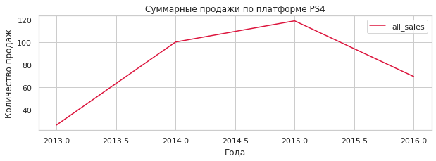

```python
games[games['platform'] == "PS4"].pivot_table(index='year_of_release', values='all_sales',
                                              aggfunc='sum').plot(kind='line',
                                                                  grid=True, figsize=(10,3), color='crimson')
plt.title("Суммарные продажи по платформе PS4")
plt.xlabel("Года")
plt.ylabel("Количество продаж")
plt.show()
```

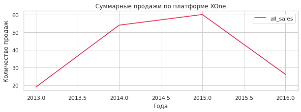

```python
games[games['platform'] == "XOne"].pivot_table(index='year_of_release', values='all_sales',
                                              aggfunc='sum').plot(kind='line',
                                                                  grid=True, figsize=(10,3), color='crimson')
plt.title("Суммарные продажи по платформе XOne")
plt.xlabel("Года")
plt.ylabel("Количество продаж")
plt.show()
```

Итак, по нашим графикам прослеживается, что в основном платформы проходят этап появления-спада за 8-10 лет. Далее определим некий актуальный период.

Несмотря на то, что продажи многих платформ уже пошли на спад к 2013, новые платформы (например PS4, XOne и др.) только начинали развиваться в это время. Поэтому **наиболее актуальным периодом для анализа считаю 2013-2016 гг**. Далее будем использовать их.

```python
#выделим данные по новым актуальным годам
new_games = games.query('year_of_release >= 2013')
new_games
```

|  | name | platform | year_of_release | genre | na_sales | eu_sales | jp_sales | other_sales | critic_score | user_score | rating | all_sales |
| --- | --- | --- | --- | --- | --- | --- | --- | --- | --- | --- | --- | --- |
| 16 | Grand Theft Auto V | PS3 | 2013 | Action | 7.02 | 9.09 | 0.98 | 3.96 | 97.0 | 8.2 | M | 21.05 |
| 23 | Grand Theft Auto V | X360 | 2013 | Action | 9.66 | 5.14 | 0.06 | 1.41 | 97.0 | 8.1 | M | 16.27 |
| 31 | Call of Duty: Black Ops 3 | PS4 | 2015 | Shooter | 6.03 | 5.86 | 0.36 | 2.38 | NaN | NaN | without | 14.63 |
| 33 | Pokemon X/Pokemon Y | 3DS | 2013 | Role-Playing | 5.28 | 4.19 | 4.35 | 0.78 | NaN | NaN | without | 14.60 |
| 42 | Grand Theft Auto V | PS4 | 2014 | Action | 3.96 | 6.31 | 0.38 | 1.97 | 97.0 | 8.3 | M | 12.62 |
| ... | ... | ... | ... | ... | ... | ... | ... | ... | ... | ... | ... | ... |
| 16701 | Strawberry Nauts | PSV | 2016 | Adventure | 0.00 | 0.00 | 0.01 | 0.00 | NaN | NaN | without | 0.01 |
| 16705 | Aiyoku no Eustia | PSV | 2014 | Misc | 0.00 | 0.00 | 0.01 | 0.00 | NaN | NaN | without | 0.01 |
| 16708 | Samurai Warriors: Sanada Maru | PS3 | 2016 | Action | 0.00 | 0.00 | 0.01 | 0.00 | NaN | NaN | without | 0.01 |
| 16710 | Haitaka no Psychedelica | PSV | 2016 | Adventure | 0.00 | 0.00 | 0.01 | 0.00 | NaN | NaN | without | 0.01 |
| 16712 | Winning Post 8 2016 | PSV | 2016 | Simulation | 0.00 | 0.00 | 0.01 | 0.00 | NaN | NaN | without | 0.01 |

2233 rows × 12 columns

```python
new_games.info()
```

```
<class 'pandas.core.frame.DataFrame'>
Int64Index: 2233 entries, 16 to 16712
Data columns (total 12 columns):
 #   Column           Non-Null Count  Dtype
---  ------           --------------  -----
 0   name             2233 non-null   object
 1   platform         2233 non-null   object
 2   year_of_release  2233 non-null   Int32
 3   genre            2233 non-null   object
 4   na_sales         2233 non-null   float64
 5   eu_sales         2233 non-null   float64
 6   jp_sales         2233 non-null   float64
 7   other_sales      2233 non-null   float64
 8   critic_score     991 non-null    float64
 9   user_score       1192 non-null   float32
 10  rating           2233 non-null   object
 11  all_sales        2233 non-null   float64
dtypes: Int32(1), float32(1), float64(6), object(4)
memory usage: 211.5+ KB
```

**Далее определим, какие платформы лидируют по продажам**

```python
#Узнаем, какие платформы остались
new_games['platform'].unique()
```

```
array(['PS3', 'X360', 'PS4', '3DS', 'XOne', 'WiiU', 'Wii', 'PC', 'PSV',
       'DS', 'PSP'], dtype=object)
```

```python
#Найдем лидеров по продажам
new_games_pt = new_games.pivot_table(
                                 index = ['platform'],
                                 values = ['all_sales'],
                                 aggfunc =  ['sum'])
new_games_pt.sort_values(('sum', 'all_sales'),ascending = False)
```

| platform | sum all_sales |
| --- | --- |
| PS4 | 314.14 |
| PS3 | 181.43 |
| XOne | 159.32 |
| 3DS | 143.25 |
| X360 | 136.80 |
| WiiU | 64.63 |
| PC | 39.43 |
| PSV | 32.99 |
| Wii | 13.66 |
| PSP | 3.50 |
| DS | 1.54 |

Так, по продажам лидируют: PS4, PS3, XOne, 3DS, X360

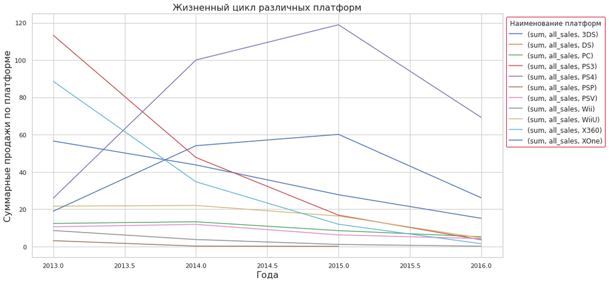

```python
new_games_for_year = new_games.pivot_table(
                                 index = ['year_of_release'],
                                 columns = ['platform'],
                                 values = ['all_sales'],
                                 aggfunc =  ['sum'])
new_games_for_year.plot(figsize = (15,8))
plt.title('Жизненный цикл различных платформ', fontsize=16)
plt.xlabel('Года', fontsize=16)
plt.ylabel('Суммарные продажи по платформе', fontsize=16)
plt.legend(bbox_to_anchor=(1, 1), title='Наименование платформ', framealpha=1, edgecolor='crimson', fontsize=12)
plt.show()
```

Из наших наиболее прибыльных платформ (PS4, PS3, XOne, 3DS, X360) все из них по прибыли уже пошли на спад. Если все же выбирать наиболее перспективными, то такими будем считать PS4, XOne, поскольку хоть они и идут на спад по прибыли, но все же их прибыль высока по сравнению с остальными.

**Далее построим график «ящик с усами» по глобальным продажам игр в разбивке по платформам**

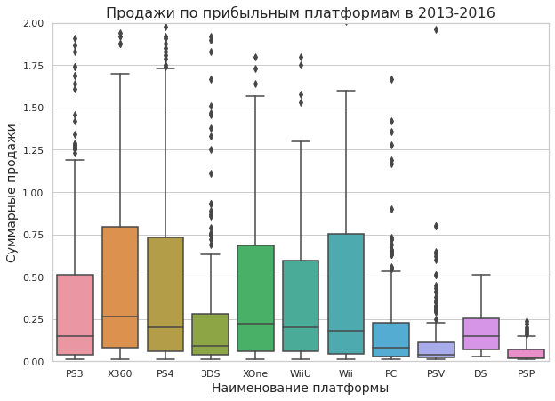

```python
plt.figure(figsize=(10,7))
sns.boxplot(data=new_games, x='platform', y='all_sales')
plt.title('Продажи по прибыльным платформам в 2013-2016', fontsize=16)
plt.xlabel('Наименование платформы', fontsize=14)
plt.ylabel('Суммарные продажи', fontsize=14)
plt.ylim(0, 2)
plt.show()
```

Так, по графику видно, что:

1. Наибольшие медианные суммарные продажи за 2013-2016 у платформы X360. Также они высоки у платформ XOne, WiiU, PS4. Наименьшие - у PSP.
2. Почти все платформы имеют выбросы. Быть может это связано с продажей крайне успешных игр-бестселлеров.
3. По межквартильному размаху на первом месте находится X360, на втором - wii, а на третьем - PS4. на самом последнем месте находится PSP.
4. В обоих случаях: лидер - X360, на последнем месте - PSP.

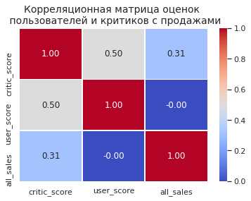

```python
plt.figure(figsize=(6, 4))
# Получаем данные и строим корреляционную матрицу
corr_matrix = new_games.drop(['year_of_release', 'na_sales', 'eu_sales', 'jp_sales', 'other_sales'], axis=1).corr()
# Строим тепловую карту
sns.heatmap(corr_matrix, annot=True, cmap='coolwarm', fmt=".2f", linewidths=0.5)
plt.title('Корреляционная матрица оценок \n пользователей и критиков с продажами', fontsize=14)

plt.show()
```

Так, мы видим, что в целом по всем платформам за 2013-2016 на продажи почти никак не влияли отзывы пользователей, а также совсем немного влияли отзывы критиков. Разберем более детально с разбивкой по платформам.

**Далее посмотрим, как влияют на продажи внутри одной популярной платформы отзывы пользователей и критиков**

Возьмем для анализа платформу: X360.

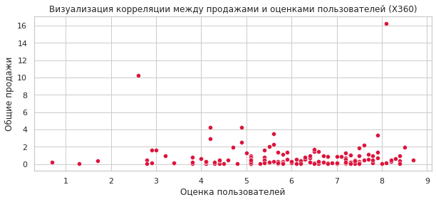

```python
#выбираем нашу платформу и сортируем
x360_corr = new_games.query('platform == "X360"')
x360_corr = x360_corr.sort_values('user_score',ascending = False)

#Строим диаграмму рассеяния влияния отзывов пользователей на продажи
x360_corr_2 = sns.scatterplot(data = x360_corr, x = 'user_score',y = 'all_sales', color='crimson')
x360_corr_2.figure.set_figwidth(10)
x360_corr_2.figure.set_figheight(4)
plt.xlabel('Оценка пользователей')
plt.ylabel('Общие продажи')
plt.title('Визуализация корреляции между продажами и оценками пользователей (X360)')
plt.grid(True)
plt.show()
```

```python
#подсчитываем корреляцию
x360_corr['user_score'].corr(x360_corr['all_sales'])
```

```
-0.011742173023024492
```

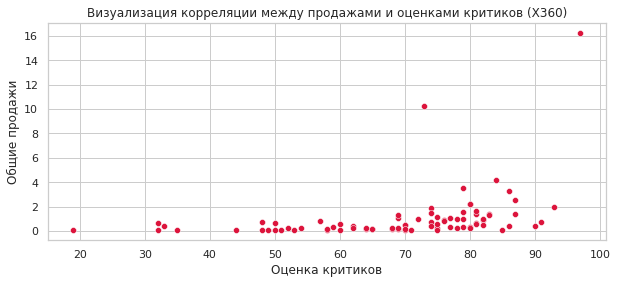

```python
#выбираем нашу платформу и сортируем
x360_corr_3 = new_games.query('platform == "X360"')
x360_corr_3 = x360_corr.sort_values('critic_score',ascending = False)

#Строим диаграмму рассеяния влияния отзывов критиков на продажи
x360_corr_4 = sns.scatterplot(data = x360_corr, x = 'critic_score',y = 'all_sales', color='crimson')
x360_corr_4.figure.set_figwidth(10)
x360_corr_4.figure.set_figheight(4)
plt.xlabel('Оценка критиков')
plt.ylabel('Общие продажи')
plt.title('Визуализация корреляции между продажами и оценками критиков (X360)')
plt.grid(True)
plt.show()
```

```python
#подсчитываем корреляцию
x360_corr['critic_score'].corr(x360_corr['all_sales'])
```

```
0.3503445460228664
```

Итак, мы увидели, что оценки пользователей практически никак не влияют на продажи игр. Корреляция в данном случае близка к нулю.

Оценки критиков влияют на продажи больше, чем оценки пользователей. Однако, коэффициент корреляции все равно мал. Зависимость можно считать прямой и умеренной.

Попробуем взять еще две популярные платформы (PS4, Xone) и посмотреть коэф. корреляции продаж и оценок критиков и пользователей с ними.

**PS4:**

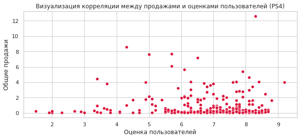

```python
#выбираем нашу платформу и сортируем
ps4_corr = new_games.query('platform == "PS4"')
ps4_corr = ps4_corr.sort_values('user_score',ascending = False)

#Строим диаграмму рассеяния влияния отзывов пользователей на продажи
ps4_corr = sns.scatterplot(data = ps4_corr, x = 'user_score',y = 'all_sales', color='crimson')
ps4_corr.figure.set_figwidth(10)
ps4_corr.figure.set_figheight(4)
plt.xlabel('Оценка пользователей')
plt.ylabel('Общие продажи')
plt.title('Визуализация корреляции между продажами и оценками пользователей (PS4)')
plt.grid(True)
plt.show()
```

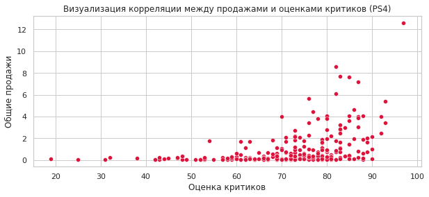

```python
#выбираем нашу платформу и сортируем
ps4_corr_2 = new_games.query('platform == "PS4"')
ps4_corr_2 = ps4_corr_2.sort_values('critic_score',ascending = False)

#Строим диаграмму рассеяния влияния отзывов критиков на продажи
ps4_corr_2 = sns.scatterplot(data = ps4_corr_2, x = 'critic_score',y = 'all_sales', color='crimson')
ps4_corr_2.figure.set_figwidth(10)
ps4_corr_2.figure.set_figheight(4)
plt.xlabel('Оценка критиков')
plt.ylabel('Общие продажи')
plt.title('Визуализация корреляции между продажами и оценками критиков (PS4)')
plt.grid(True)
plt.show()
```

```python
ps4_corr_3 = new_games.query('platform == "PS4"')
ps4_corr_3 = ps4_corr_3.sort_values('user_score',ascending = False)
display(ps4_corr_3['user_score'].corr(ps4_corr_3['all_sales']))
display(ps4_corr_3['critic_score'].corr(ps4_corr_3['all_sales']))
```

```
-0.03195710900518826
```

```
0.40656790206178134
```

**Xone:**

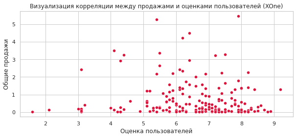

```python
#выбираем нашу платформу и сортируем
xone_corr = new_games.query('platform == "XOne"')
xone_corr = xone_corr.sort_values('user_score',ascending = False)

#Строим диаграмму рассеяния влияния отзывов пользователей на продажи
xone_corr = sns.scatterplot(data = xone_corr, x = 'user_score',y = 'all_sales', color='crimson')
xone_corr.figure.set_figwidth(10)
xone_corr.figure.set_figheight(4)
plt.xlabel('Оценка пользователей')
plt.ylabel('Общие продажи')
plt.title('Визуализация корреляции между продажами и оценками пользователей (XOne)')
plt.grid(True)
plt.show()
```

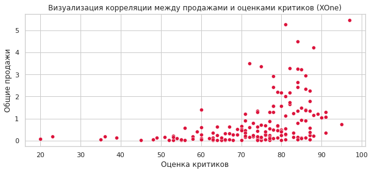

```python
#выбираем нашу платформу и сортируем
xone_corr_2 = new_games.query('platform == "XOne"')
xone_corr_2 = xone_corr_2.sort_values('critic_score',ascending = False)

#Строим диаграмму рассеяния влияния отзывов критиков на продажи
xone_corr_2 = sns.scatterplot(data = xone_corr_2, x = 'critic_score',y = 'all_sales', color='crimson')
xone_corr_2.figure.set_figwidth(10)
xone_corr_2.figure.set_figheight(4)
plt.xlabel('Оценка критиков')
plt.ylabel('Общие продажи')
plt.title('Визуализация корреляции между продажами и оценками критиков (XOne)')
plt.grid(True)
plt.show()
```

```python
xone_corr_3 = new_games.query('platform == "XOne"')
xone_corr_3 = xone_corr_3.sort_values('user_score',ascending = False)
display(xone_corr_3['user_score'].corr(xone_corr_3['all_sales']))
display(xone_corr_3['critic_score'].corr(xone_corr_3['all_sales']))
```

```
-0.06892505319711205
```

```
0.4169983280084016
```

Так, мы увидели, что во всех трех случаях картина примерно одинаковая: оценки пользователей не влияют на продажи игр (причем даже зависимость здесь обратная), а вот оценки критиков умеренно влияют на продажи игр.

Наибольший коэф. корреляции в случае с XOne, наименьший - в случае с x360.

**Далее рассмотрим общее распределение игр по жанрам**

```python
#По сумме общих продаж
genre_pt = pd.pivot_table(new_games, index='genre', values='all_sales', aggfunc='sum').\
sort_values('all_sales', ascending=False)
genre_pt
```

| genre | all_sales |
| --- | --- |
| Action | 321.87 |
| Shooter | 232.98 |
| Sports | 150.65 |
| Role-Playing | 145.89 |
| Misc | 62.82 |
| Platform | 42.63 |
| Racing | 39.89 |
| Fighting | 35.31 |
| Adventure | 23.64 |
| Simulation | 21.76 |
| Strategy | 10.08 |
| Puzzle | 3.17 |

```python
#По медианным продажам
genre_pt = pd.pivot_table(new_games, index='genre', values='all_sales', aggfunc='median').\
sort_values('all_sales', ascending=False)
genre_pt
```

| genre | all_sales |
| --- | --- |
| Shooter | 0.450 |
| Sports | 0.240 |
| Platform | 0.225 |
| Role-Playing | 0.125 |
| Fighting | 0.125 |
| Racing | 0.120 |
| Action | 0.110 |
| Simulation | 0.100 |
| Misc | 0.100 |
| Strategy | 0.080 |
| Puzzle | 0.060 |
| Adventure | 0.030 |

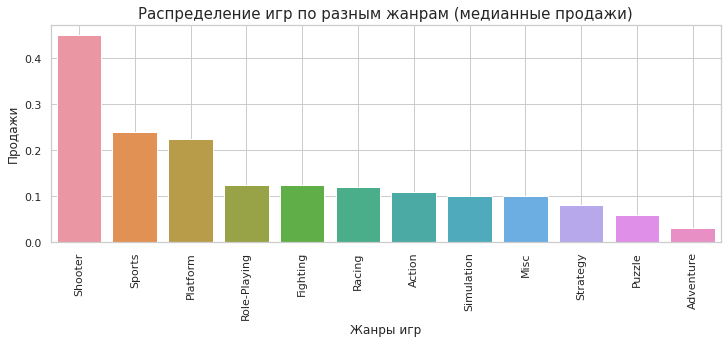

```python
genre_pt = pd.pivot_table(new_games, index='genre', values='all_sales', aggfunc='median').sort_values('all_sales', ascending=False)
plt.figure(figsize=(12, 4))
plt.title('Распределение игр по разным жанрам (медианные продажи)', fontsize=15)
sns.barplot(data=genre_pt, x=genre_pt.index, y='all_sales')
plt.xlabel('Жанры игр', fontsize=12)
plt.ylabel('Продажи', fontsize=12)
plt.xticks(rotation=90)
plt.grid(True)
plt.show()
```

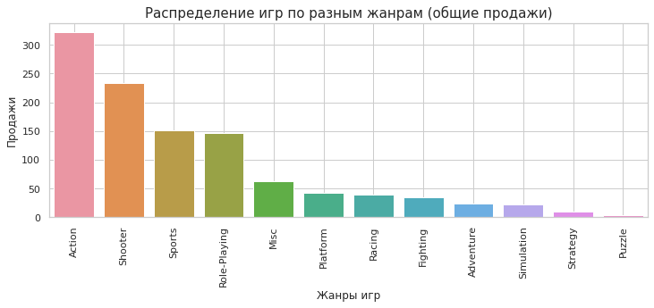

```python
genre_pt = pd.pivot_table(new_games, index='genre', values='all_sales', aggfunc='sum').sort_values('all_sales', ascending=False)
plt.figure(figsize=(12, 4))
plt.title('Распределение игр по разным жанрам (общие продажи)', fontsize=15)
sns.barplot(data=genre_pt, x=genre_pt.index, y='all_sales')
plt.xlabel('Жанры игр', fontsize=12)
plt.ylabel('Продажи', fontsize=12)
plt.xticks(rotation=90)
plt.grid(True)
plt.show()
```

Итак, как мы видим, тремя наиболее популярными жанрами по общим продажам являются action, shooter, sports. Однако наиболее прибыльными по медианным продажам являются Shooter, Sports, Platform. Самыми бесперспективными играми оказались puzzle и adventure.

**Вывод по исследовательскому анализу данных:**

В основном платформы проходят этап появления-спада за 8-10 лет. Наиболее актуальным периодом для анализа считаю 2013-2016 гг.

Из наших наиболее прибыльных платформ (PS4, PS3, XOne, 3DS, X360) все из них по прибыли уже пошли на спад. Если все же выбирать наиболее перспективными, то такими будем считать PS4, XOne, поскольку хоть они и идут на спад по прибыли, но все же их прибыль высока по сравнению с остальными.

Наибольшие медианные суммарные продажи за 2013-2016 у платформы X360. Также они высоки у платформ XOne, WiiU, PS4. Наименьшие - у PSP. Почти все платформы имеют выбросы. Быть может это связано со скидками на игры или же с бесплатной раздачей каких-либо игр.

В целом по всем платформам за 2013-2016 на продажи почти никак не влияли отзывы пользователей, а также совсем немного влияли отзывы критиков.

В разбивке по платформам: оценки пользователей не влияют на продажи игр (причем даже зависимость здесь обратная), а вот оценки критиков умеренно влияют на продажи игр. Наибольший коэф. корреляции (анализируя PS4, XOne и X360) в случае с XOne, наименьший - в случае с x360.

Итак, как мы видим, тремя наиболее популярными жанрами по общим продажам являются action, shooter, sports. Однако наиболее прибыльными по медианным продажам являются Shooter, Sports, Platform. Самыми бесперспективными играми оказались puzzle и adventure.

## Портрет пользователя каждого региона

Мы имеем следующие регионы: NA, EU, JP и другие. Для каждого из них определим:

[output not shown]

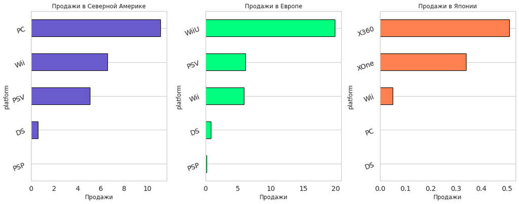

```python
def top_5(groupby, region_sales, ax):
    pivot = new_games.groupby(groupby).agg({region_sales: 'sum'}).sort_values(by=region_sales)[:5]
    title_plot = {'na_sales': 'Продажи в Северной Америке', 'eu_sales': 'Продажи в Европе',
                  'jp_sales': 'Продажи в Японии'}
    color_plot = {'na_sales': 'slateblue', 'eu_sales': 'springgreen', 'jp_sales': 'coral'}
    plot = pivot.plot(kind='barh', edgecolor='black', title=title_plot[region_sales], ax=axes[ax],
                   fontsize=14, color=color_plot[region_sales], rot=20, legend=None)
    plot.set_xlabel('Продажи')

    plot.grid(axis='x', alpha=0.5)

fig, axes = plt.subplots(1, 3, figsize=(15, 6))
top_5('platform', 'na_sales', 0)
top_5('platform', 'eu_sales', 1)
top_5('platform', 'jp_sales', 2)
plt.tight_layout()
plt.show()
```

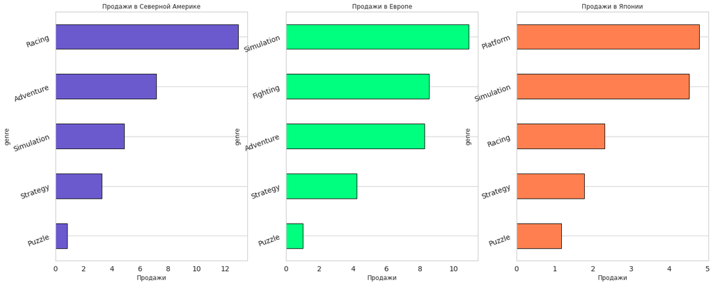

```python
#Визуализируем топ-5 жанров по регионам
fig, axes = plt.subplots(1, 3, figsize=(23,9))
top_5('genre', 'na_sales', 0)
top_5('genre', 'eu_sales', 1)
top_5('genre', 'jp_sales', 2)
```

Полагаю, что это так или иначе связано с менталитетом регионов, с вкусовыми предпочтениями жителей разных стран.

**Узнаем влияет ли рейтинг ESRB на продажи в отдельном регионе**

```python
#Посмотрим какие типы рейтинга ESRB вообще есть
new_games['rating'].unique()
```

```
array(['M', 'without', 'E', 'T', 'E10+'], dtype=object)
```

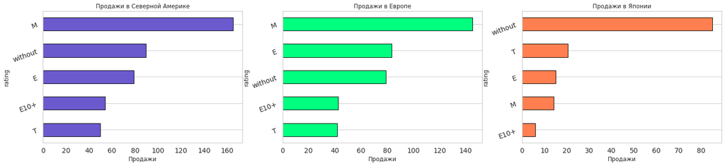

```python
#Визуализируем рейтинг ESRB по регионам
fig, axes = plt.subplots(1, 3, figsize=(25, 5))

top_5('rating', 'na_sales', 0)
top_5('rating', 'eu_sales', 1)
top_5('rating', 'jp_sales', 2)
```

Далее для полноты картины следует привести расшифровку рейтинга ESRB:

E = игра для всех

E10+ = для пользователей старше 10 лет

T = для пользователей старше 13 лет

M = для пользователей старше 17 лет

Группа с названием "without" - это группа игр, не имеющих рейтинг.

Так, по графикам можно заметить, что везде, кроме Японии, наиболее популярными являются игры с рейтингом ESRB - M (для пользователей старше 17 лет). Однако в Японии ситуация совершенно иная. Наиболее популярными в Японии являются игры без рейтинга, а за ними идут игры с рейтингом T (для пользователей старше 13 лет). Также стоит отметить, что во всех регионах много игр без рейтинга вообще и игр с рейтингом E(игра для всех пользователей).

В Северной Америке и Европе на последнем месте оказались игры с рейтингом T (для пользователей старше 13 лет). Для Японии самым неперспективным рейтингом игр является E+10, что означает для пользователей старше 10 лет.

## Проверка гипотез

### Гипотеза 1

**Средние пользовательские рейтинги платформ Xbox One и PC одинаковые**

Определим нулевую и анльтернативную гипотезы.

Н0: Средний пользовательский рейтинг платформ Xbox One и PC одинаковый

H1: Средний пользовательский рейтинг платформ Xbox One и PC различается

```python
select_xone = new_games[new_games['platform']=="XOne"]['user_score'].dropna()
select_pc = new_games[new_games['platform']=="PC"]['user_score'].dropna()

alpha = 0.01

results = st.ttest_ind(select_xone, select_pc)

print('p-значение:', results.pvalue)

if (results.pvalue < alpha):
    print("Отвергаем нулевую гипотезу")
else:
    print("Не получилось отвергнуть нулевую гипотезу")
```

```
p-значение: 0.14012765210016784
Не получилось отвергнуть нулевую гипотезу
```

Для оценки гипотезы применили тест Стьюдента. Значение pvalue = 14%. Это означает, что нулевую гипотезу отвергнуть не удалось. Предполагаем, что все-таки средний пользовательский рейтинг платформ Xbox One и PC одинаковый. Проверим с помощью средних велечин:

```python
select_xone = new_games[new_games['platform']=="XOne"]['user_score'].dropna().mean()
select_xone
```

```
6.521428
```

```python
select_pc = new_games[new_games['platform']=="PC"]['user_score'].dropna().mean()
select_pc
```

```
6.2696776
```

Средние велечины подтвердили нашу нулевую гипотезу, поскольку они не сильно различаются между собой.

### Гипотеза 2

**Средние пользовательские рейтинги жанров Action (англ. «действие», экшен-игры) и Sports (англ. «спортивные соревнования») разные.**

Определим нулевую и анльтернативную гипотезы.

H0: Средние пользовательские рейтинги жанров Action и Sports одинаковые

H1: Средние пользовательские рейтинги жанров Action и Sports различаются

```python
select_action = new_games[new_games['genre']=="Action"]['user_score'].dropna()
select_sports = new_games[new_games['genre']=="Sports"]['user_score'].dropna()

alpha = 0.01

results = st.ttest_ind(select_action, select_sports)

print('p-значение:', results.pvalue)

if (results.pvalue < alpha):
    print("Отвергаем нулевую гипотезу")
else:
    print("Не получилось отвергнуть нулевую гипотезу")
```

```
p-значение: 1.0517772011408453e-27
Отвергаем нулевую гипотезу
```

```python
select_action = new_games[new_games['genre']=="Action"]['user_score'].dropna().mean()
select_action
```

```
6.837532
```

```python
select_sports = new_games[new_games['genre']=="Sports"]['user_score'].dropna().mean()
select_sports
```

```
5.238125
```

Так, средние велечины в какой-то степени могут подтвердить наш вывод про отвержение нулевой гипотезы, поскольку они различаются более чем на 1.5 значение.

## Вывод

На этапе **исследовательского анализа** было выявлено, что в основном платформы проходят этап появления-спада за 8-10 лет. Наиболее актуальным периодом для анализа считаю 2013-2016 гг.

Из наших наиболее прибыльных платформ (PS4, PS3, XOne, 3DS, X360) все из них по прибыли уже пошли на спад. Если все же выбирать наиболее перспективными, то такими будем считать PS4, XOne, поскольку хоть они и идут на спад по прибыли, но все же их прибыль высока по сравнению с остальными.

Наибольшие медианные суммарные продажи за 2013-2016 у платформы X360. Также они высоки у платформ XOne, WiiU, PS4. Наименьшие - у PSP. Почти все платформы имеют выбросы. Быть может это связано с продажей крайне успешных игр-бестселлеров. По межквартильному размаху на первом месте находится X360, на втором - wii, а на третьем - PS4. на самом последнем месте находится PSP. В обоих случаях: лидер - X360, на последнем месте - PSP.

В целом по всем платформам за 2013-2016 на продажи почти никак не влияли отзывы пользователей, а также совсем немного влияли отзывы критиков.

В разбивке по платформам: оценки пользователей не влияют на продажи игр (причем даже зависимость здесь обратная), а вот оценки критиков умеренно влияют на продажи игр. Наибольший коэф. корреляции (анализируя PS4, XOne и X360) в случае с XOne, наименьший - в случае с x360.

Тремя наиболее популярными жанрами по продажам являются action, shooter, sports. Самыми продаваемыми играми являются игры жанра action на платформе PS4. Самым плохо продаваемым жанром игр является puzzle. Самые продаваемые - это игры, выпускаемые для PS4, PS3, XOne, X360, 3DS.

**На этапе проверки гипотез было выявлено, что:**

**1 гипотеза.** Средние пользовательские рейтинги платформ Xbox One и PC одинаковые

Н0: Средний пользовательский рейтинг платформ Xbox One и PC одинаковый

H1: Средний пользовательский рейтинг платформ Xbox One и PC различается

Для оценки гипотезы применили тест Стьюдента. Значение pvalue = 14%. Это означает, что нулевую гипотезу отвергнуть не удалось. Предполагаем, что все-таки средний пользовательский рейтинг платформ Xbox One и PC одинаковый.

**2 гипотеза.** Средние пользовательские рейтинги жанров Action (англ. «действие», экшен-игры) и Sports (англ. «спортивные соревнования») разные.

H0: Средние пользовательские рейтинги жанров Action и Sports одинаковые

H1: Средние пользовательские рейтинги жанров Action и Sports различаются